# Run QC - Demultiplexed FastQs

M Fisher

2022-09-27

# Description

Graph the distribution of read depths from MiSeq sequencing output, and look at base pair quality along the length of the sequence.

Dependencies: Run the bash script `00_get_fastq_read_depth.sh` from the command line (or by double clicking it) to determine the number of reads in the fastq files (counts the lines and divides by 4).

# Run 1

This sequencing run was completed at UCLA.

The sequence quality section requires the location of the fastq files:

```r
fastq_dir <- "data/raw/run_1"
```

```
## # A tibble: 6 x 8
##   `flowcell-id`   name    name2      name3        number Barco~1 Perfe~2 OneMi~3
##   <chr>           <chr>   <chr>      <chr>         <dbl>   <dbl>   <dbl>   <dbl>
## 1 000000000-KCWYV default 1_KAY_01-a GAACTGAGCG+~      1  202986  191478   11508
## 2 000000000-KCWYV default 1_KAY_01-a all               1  202986  191478   11508
## 3 000000000-KCWYV default 2_KAY_01-b AGGTCAGATA+~      1  213095  198946   14149
## 4 000000000-KCWYV default 2_KAY_01-b all               1  213095  198946   14149
## 5 000000000-KCWYV default 3_KAY_01-c CGTCTCATAT+~      1  252582  241348   11234
## 6 000000000-KCWYV default 3_KAY_01-c all               1  252582  241348   11234
## # ... with abbreviated variable names 1: BarcodeCount, 2: PerfectBarcodeCount,
## #   3: OneMismatchBarcodeCount
```

## Read depth (MiSeq Stats)

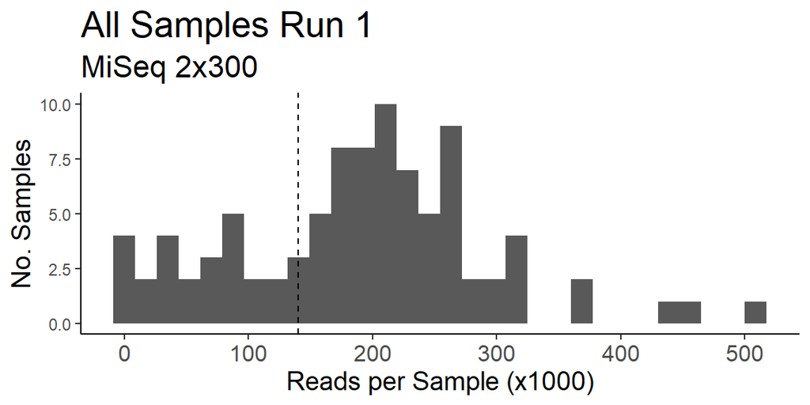

*I believe these are total forward and reverse reads, so a cutoff of 70,000 reads per direction would be x=140 (vertical dashed line above)*

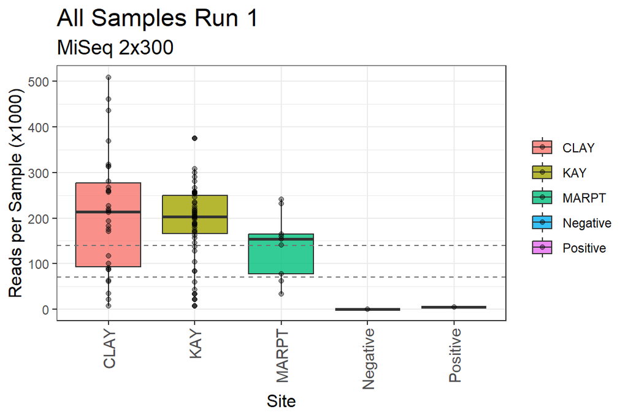

Which samples have zero reads? *None!*

```
## # A tibble: 0 x 7
## # ... with 7 variables: miseq_id <chr>, sample_name <chr>, site <chr>,
## #   sample_id <chr>, rep <chr>, barcode <chr>, nreads <dbl>
```

Which samples have fewer than 20,000 reads (10,000 in each direction)

```
## # A tibble: 4 x 7
##   miseq_id            sample_name site     sample_id rep   barcode        nreads
##   <chr>               <chr>       <chr>    <chr>     <chr> <chr>           <dbl>
## 1 15_KAY_05-c         15          KAY      05        c     TCCATTGCCG+GA~   6841
## 2 85_CLAY_06-a        85          CLAY     06        a     TGGTACCTAA+CA~   7481
## 3 95_Positive_Control 95          Positive Control   <NA>  GTATTCCACC+AT~   5334
## 4 96_Negative_Control 96          Negative Control   <NA>  CCTCCGTCCA+CA~     38
```

Which samples had a very large number of reads? *CLAY_05*

```
## # A tibble: 3 x 7
##   miseq_id     sample_name site  sample_id rep   barcode               nreads
##   <chr>        <chr>       <chr> <chr>     <chr> <chr>                  <dbl>
## 1 82_CLAY_05-a 82          CLAY  05        a     ACCGTTACAA+CTCATAGCGA 435831
## 2 83_CLAY_05-b 83          CLAY  05        b     TATGCCTTAC+AGACACATTA 460608
## 3 84_CLAY_05-c 84          CLAY  05        c     ACAAGTGGAC+GCGCGATGTT 508975
```

## Read depth (Fastq)

This is the read depth determined using the fastq files.

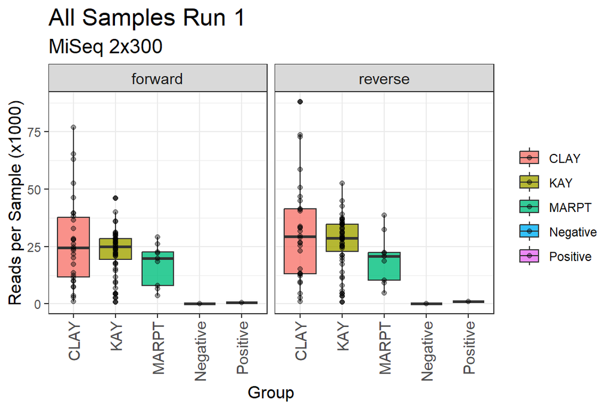

## Check read quality

Look into a subset of the samples.

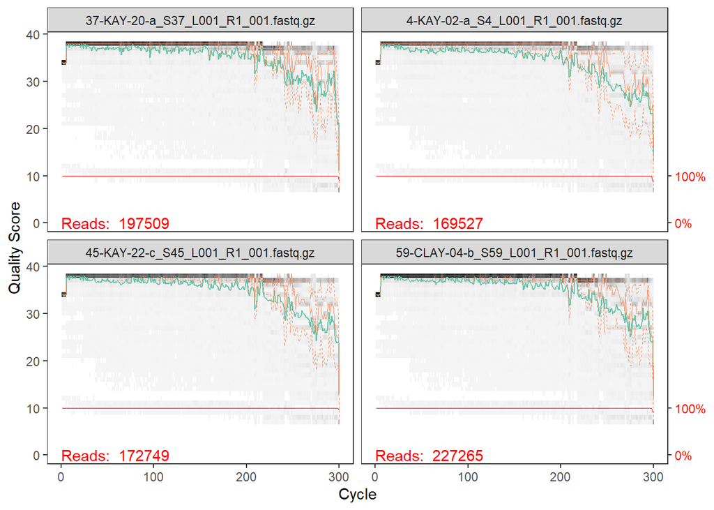

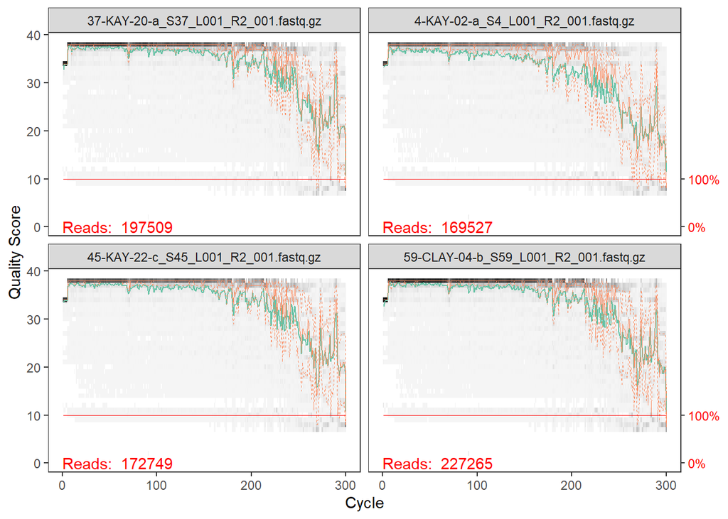

# Run 2

This sequencing run was completed at the Center for Environmental Genomics, on the Kelly Lab MiSeq

The sequence quality section requires the location of the fastq files:

```r
fastq_dir2 <- "data/raw/run_2"
```

## Read Depth (FastQ)

This is the read depth determined using the fastq files.

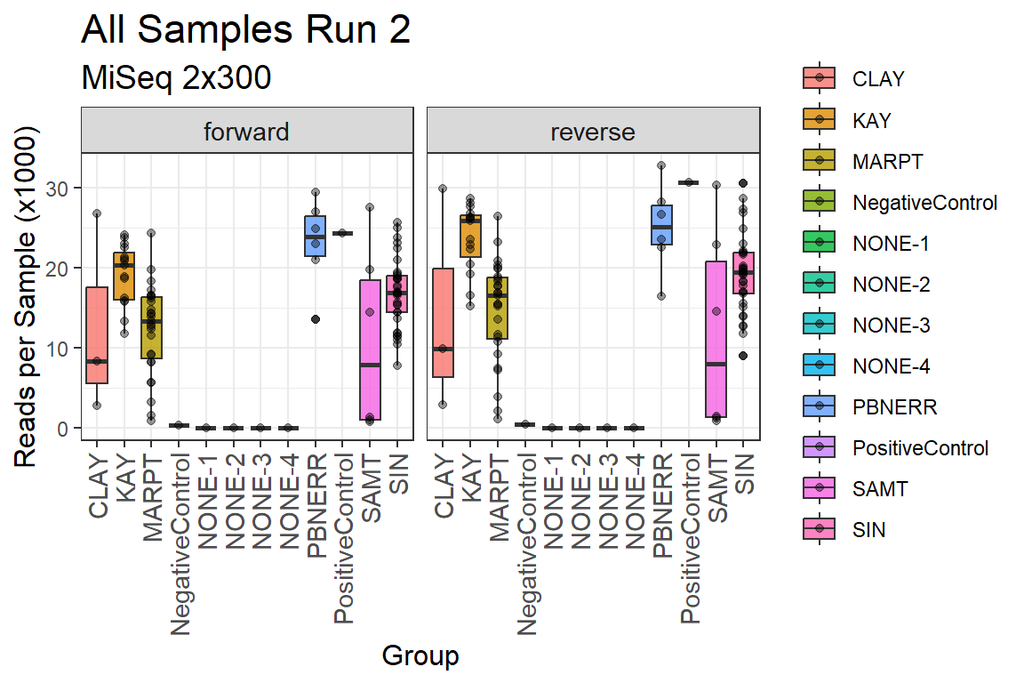

Good that there aren’t reads in the “NONE” samples, which were indices that I didn’t include in this run; and in the Negative Control. The Positive Control has a lot of reads, hopefully that’s all roo.

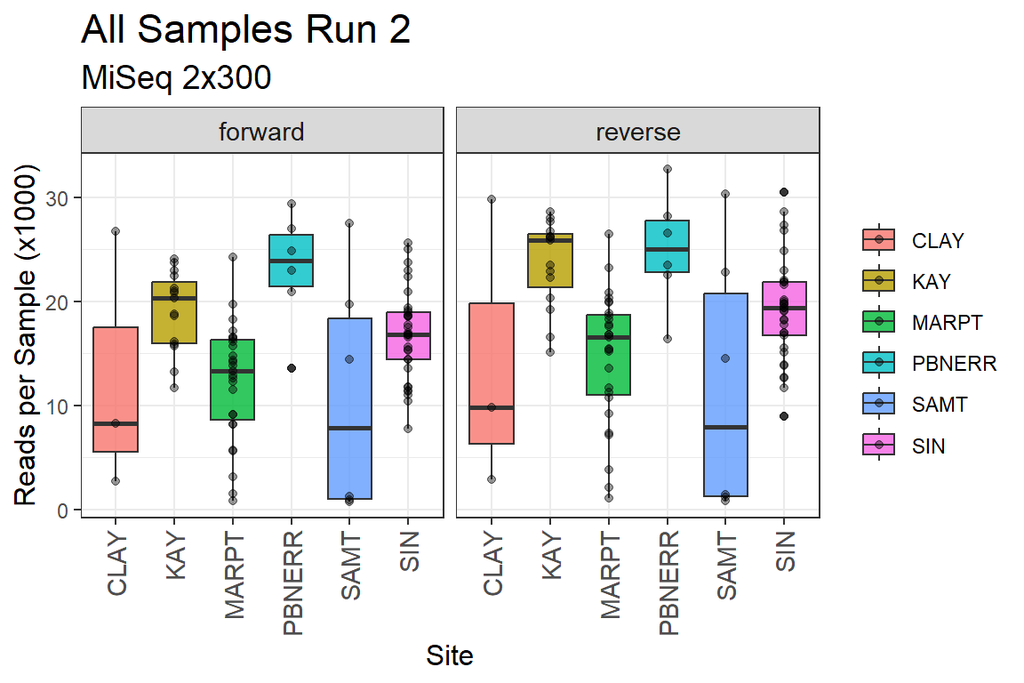

## Check read quality

Look into a subset of the samples.

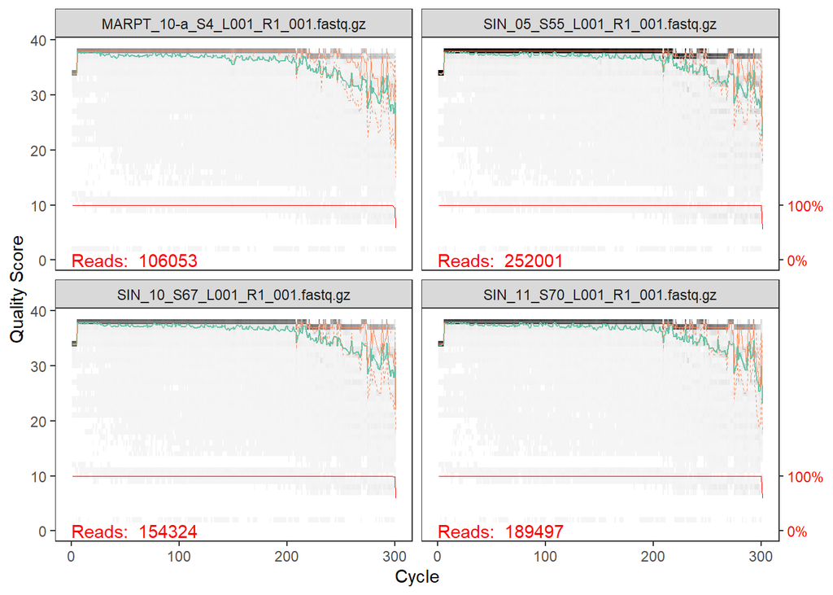

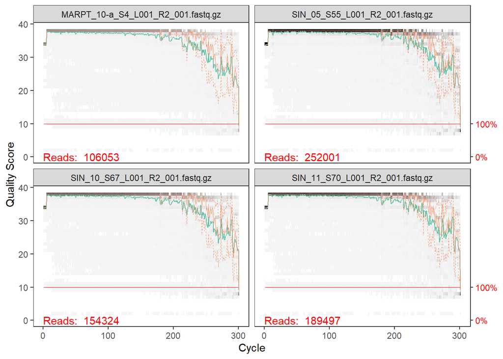

# Read Counts across Runs

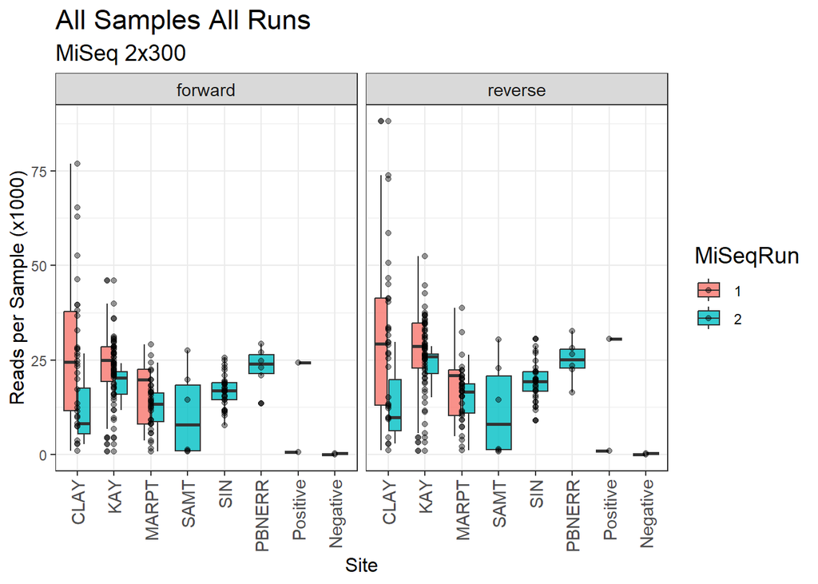